# GoogleDataAnalyticsCaseStudy

Thinh Phan

2023-02-07

# DivvyBikeCase

## Introduction

-Scenario: I am a junior data analyst working in the marketing analyst team at Cyclistic, a bike-share company in Chicago. Lily Moreno, the director of marketing team asked us: “How do annual members and casual riders use Cyclistic bikes differently?”, so we can design a new marketing strategy to convert riders into annual members. Our team will create report with compelling data insight and professional data visualization.

-Cyclistic has a flexibility pricing plans: single-ride passes, full-day passes, and annual memberships. Customers who purchase single-ride or full-day passes are referred to as casual riders. Customers who purchase annual memberships are Cyclistic members. **Note: Cyclistic is a fictional company and the dataset is used for completing the study case**

## Characters and teams

-Cyclistic: A bike-share program in Chicago that offering reclining bikes, hand tricycles, and cargo bikes.

-Lily Moreno: The director of marketing and manager, who is responsible for advertise bike-share program.

-Cyclistic marketing analytics team: A team of data analysts who are responsible for collecting, analyzing, and reporting data that helps guide Cyclistic marketing strategy.

-Cyclistic executive team: a detail-oriented team that will decide whether to approve the recommend marketing program.

**To answer the question, we will stick to data analytics process, according to Google(ask,prepare,process,analyze,share,act)**

## Ask

-Our business task is “How do annual members and casual riders use Cyclistic bikes differently?”. At this step since we don’t have data yet, using SMART (specific, measure, action-oriented, relevant, time-bound) to ask Lily(stakeholder) why does she think that would be a good idea.

-Top question would be “top 5 features difference”, “Most important difference”, “Is it worth it?”, “What will happen in near future?”.

-To solve this problem, determine how long do member/casual use bike a day and what day is that would be a key factor, since we want to track each type of riders closely day by day.

## Prepare

-Now we have data, we can begin to analyze and identify trends [All Cyclistics trip data in previous 12 months](https://divvy-tripdata.s3.amazonaws.com/index.html)

-This dataset is appropriate to the purpose of the study case, and has been make available by Motivate International Inc. under this [license](https://ride.divvybikes.com/data-license-agreement)

-To ensure data integrity, make sure to convert values into correct data types, and most importantly check **spelling** after we add another new fields.

-Since we having data now and verify, we can move to next step of the process.

-**Warning**: brace yourself because we will have to deal with large dataset and make sure to save after every step since it is very easy to crash.

## Process

-I used Mac, so after analyzing excel sheet I have to convert from .numbers to .csv to further analyze in R

-To make sure data is clean and integrity, data types must be correct, and use conditional formatting to fill out blank cell,also sort out columns especially “membercasual” columns since we need them to solve business task

-I follow steps that was suggested, by calculated “ride_length” column by subtracting end_time with start_time, then format into hh:mm:ss, and “day_of_week” column by convert start_time into weekday.

## Analysis

-Now we will begin to analyze data, after we calculate “ride_length” and “day_of_week” column, sort them out, and check out data format(day_of_week is”weekday” and ride_length is “time”).

-Then I began to create a pivot tables, to calculate average ride_length for member and casual, day_by_week and number_of_rides.

-After analyzed all 12 excels sheet, the ride_id columns has the first letter either numeric or characters, same as start_station_id and end_station_id. There is also situation that rider used bike for few seconds or none(Lily we need to talk about this?)

-Below are code chunks were used for this project (in R)

```r
# load library
library(tidyverse)
library(ggplot2)
library(lubridate)
#read excel files
m1_2022 <- read_csv("202201-divvy-tripdata.csv")
m2_2022 <- read_csv("202202-divvy-tripdata.csv")
m3_2022 <- read_csv("202203-divvy-tripdata.csv")
m4_2022 <- read_csv("202204-divvy-tripdata.csv")
m5_2022 <- read_csv("202205-divvy-tripdata.csv")
m6_2022 <- read_csv("202206-divvy-tripdata.csv")
m7_2022 <- read_csv("202207-divvy-tripdata.csv")
m8_2022 <- read_csv("202208-divvy-tripdata.csv")
m9_2022 <- read_csv("202209-divvy-tripdata.csv")
m10_2022 <- read_csv("202210-divvy-tripdata.csv")
m11_2022 <- read_csv("202211-divvy-tripdata.csv")
m12_2022 <- read_csv("202212-divvy-tripdata.csv")


#show column names
colnames(m1_2022)
```

```
##  [1] "ride_id"            "rideable_type"      "started_at"
##  [4] "ended_at"           "start_station_name" "start_station_id"
##  [7] "end_station_name"   "end_station_id"     "start_lat"
## [10] "start_lng"          "end_lat"            "end_lng"
## [13] "member_casual"      "ride_length"        "day_of_week"
```

```r
colnames(m2_2022)
```

```
##  [1] "ride_id"            "rideable_type"      "started_at"
##  [4] "ended_at"           "start_station_name" "start_station_id"
##  [7] "end_station_name"   "end_station_id"     "start_lat"
## [10] "start_lng"          "end_lat"            "end_lng"
## [13] "member_casual"      "ride_length"        "day_of_week"
```

```r
colnames(m3_2022)
```

```
##  [1] "ride_id"            "rideable_type"      "started_at"
##  [4] "ended_at"           "start_station_name" "start_station_id"
##  [7] "end_station_name"   "end_station_id"     "start_lat"
## [10] "start_lng"          "end_lat"            "end_lng"
## [13] "member_casual"      "ride_length"        "day_of_week"
```

```r
colnames(m4_2022)
```

```
##  [1] "ride_id"            "rideable_type"      "started_at"
##  [4] "ended_at"           "start_station_name" "start_station_id"
##  [7] "end_station_name"   "end_station_id"     "start_lat"
## [10] "start_lng"          "end_lat"            "end_lng"
## [13] "member_casual"      "ride_length"        "day_of_week"
```

```r
colnames(m5_2022)
```

```
##  [1] "ride_id"            "rideable_type"      "started_at"
##  [4] "ended_at"           "start_station_name" "start_station_id"
##  [7] "end_station_name"   "end_station_id"     "start_lat"
## [10] "start_lng"          "end_lat"            "end_lng"
## [13] "member_casual"      "ride_length"        "day_of_week"
```

```r
colnames(m6_2022)
```

```
##  [1] "ride_id"            "rideable_type"      "started_at"
##  [4] "ended_at"           "start_station_name" "start_station_id"
##  [7] "end_station_name"   "end_station_id"     "start_lat"
## [10] "start_lng"          "end_lat"            "end_lng"
## [13] "member_casual"      "ride_length"        "day_of_week"
```

```r
colnames(m7_2022)
```

```
##  [1] "ride_id"            "rideable_type"      "started_at"
##  [4] "ended_at"           "start_station_name" "start_station_id"
##  [7] "end_station_name"   "end_station_id"     "start_lat"
## [10] "start_lng"          "end_lat"            "end_lng"
## [13] "member_casual"      "ride_length"        "day_of_week"
```

```r
colnames(m8_2022)
```

```
##  [1] "ride_id"            "rideable_type"      "started_at"
##  [4] "ended_at"           "start_station_name" "start_station_id"
##  [7] "end_station_name"   "end_station_id"     "start_lat"
## [10] "start_lng"          "end_lat"            "end_lng"
## [13] "member_casual"      "ride_length"        "day_of_week"
```

```r
colnames(m9_2022)
```

```
##  [1] "ride_id"            "rideable_type"      "started_at"
##  [4] "ended_at"           "start_station_name" "start_station_id"
##  [7] "end_station_name"   "end_station_id"     "start_lat"
## [10] "start_lng"          "end_lat"            "end_lng"
## [13] "member_casual"      "ride_length"        "day_of_week"
```

```r
colnames(m10_2022)
```

```
##  [1] "ride_id"            "rideable_type"      "started_at"
##  [4] "ended_at"           "start_station_name" "start_station_id"
##  [7] "end_station_name"   "end_station_id"     "start_lat"
## [10] "start_lng"          "end_lat"            "end_lng"
## [13] "member_casual"      "ride_length"        "day_of_week"
```

```r
colnames(m11_2022)
```

```
##  [1] "ride_id"            "rideable_type"      "started_at"
##  [4] "ended_at"           "start_station_name" "start_station_id"
##  [7] "end_station_name"   "end_station_id"     "start_lat"
## [10] "start_lng"          "end_lat"            "end_lng"
## [13] "member_casual"      "ride_length"        "day_of_week"
```

```r
colnames(m12_2022)
```

```
##  [1] "ride_id"            "rideable_type"      "started_at"
##  [4] "ended_at"           "start_station_name" "start_station_id"
##  [7] "end_station_name"   "end_station_id"     "start_lat"
## [10] "start_lng"          "end_lat"            "end_lng"
## [13] "member_casual"      "ride_length"        "day_of_week"
```

```r
#rename columns
(m1_2022 <- rename(m1_2022
                   , trip_id = ride_id
                   ,bikeid = rideable_type
                   , start_time  = started_at
                   , end_time  = ended_at
                   ,from_station_name = start_station_name
                   , from_station_id =  start_station_id
                   , to_station_name = end_station_name
                   , to_station_id = end_station_id
                   , usertype = member_casual ))
```

```
## # A tibble: 103,770 × 15
##    trip_id        bikeid start_time          end_time            from_…¹ from_…²
##    <chr>          <chr>  <dttm>              <dttm>              <chr>   <chr>
##  1 491B5EDE565AB… class… 2022-01-30 14:24:15 2022-01-30 14:24:17 Lakevi… TA1309…
##  2 0998278DB6280… class… 2022-01-17 17:02:48 2022-01-17 17:02:50 McCorm… TA1305…
##  3 5D66288F90BBE… class… 2022-01-17 18:56:14 2022-01-17 18:56:16 Clark … TA1307…
##  4 0BF29A935AD3F… class… 2022-01-26 11:53:51 2022-01-26 11:53:53 St. Cl… 13016
##  5 861CDCB4583A2… class… 2022-01-13 13:50:48 2022-01-13 13:50:50 Cottag… KA1503…
##  6 CD481D90CF569… class… 2022-01-28 14:26:05 2022-01-28 14:26:07 Frankl… RN-
##  7 7DD7491FCB6E3… class… 2022-01-23 04:46:45 2022-01-23 04:46:48 Wells … TA1308…
##  8 6F21E2BDC3C27… class… 2022-01-12 14:09:41 2022-01-12 14:09:44 Frankl… TA1307…
##  9 8606BC2201E10… class… 2022-01-06 19:39:42 2022-01-06 19:39:45 Halste… TA1309…
## 10 C82FABB43B5CE… class… 2022-01-01 12:12:53 2022-01-01 12:12:56 Morgan… TA1308…
## # … with 103,760 more rows, 9 more variables: to_station_name <chr>,
## #   to_station_id <chr>, start_lat <dbl>, start_lng <dbl>, end_lat <dbl>,
## #   end_lng <dbl>, usertype <chr>, ride_length <chr>, day_of_week <dbl>, and
## #   abbreviated variable names ¹from_station_name, ²from_station_id
```

```r
(m2_2022 <- rename(m2_2022
                   , trip_id = ride_id
                   ,bikeid = rideable_type
                   , start_time  = started_at
                   , end_time  = ended_at
                   ,from_station_name = start_station_name
                   , from_station_id =  start_station_id
                   , to_station_name = end_station_name
                   , to_station_id = end_station_id
                   , usertype = member_casual ))
```

```
## # A tibble: 115,609 × 15
##    trip_id        bikeid start_time          end_time            from_…¹ from_…²
##    <chr>          <chr>  <dttm>              <dttm>              <chr>   <chr>
##  1 FA080339DCF1E… class… 2022-02-12 15:07:50 2022-02-12 15:07:50 Michig… TA1305…
##  2 3ED43CE541666… class… 2022-02-27 17:06:19 2022-02-27 17:06:21 Damen … KA1701…
##  3 283622C2D26AD… class… 2022-02-13 04:08:49 2022-02-13 04:08:51 Wells … TA1308…
##  4 11A8B5A3BB000… class… 2022-02-01 16:15:53 2022-02-01 16:15:55 Wester… TA1307…
##  5 E16212AD2FA8A… class… 2022-02-23 19:17:01 2022-02-23 19:17:03 Racine… TA1309…
##  6 C172EA3131EBC… class… 2022-02-04 10:26:10 2022-02-04 10:26:12 Indian… SL-005
##  7 78F722D6304ED… class… 2022-02-26 17:29:24 2022-02-26 17:29:26 Michig… 13034
##  8 416A58DD45C7A… class… 2022-02-20 09:52:04 2022-02-20 09:52:07 Wester… TA1307…
##  9 D2BC2E7074374… class… 2022-02-14 07:22:25 2022-02-14 07:22:28 Columb… 13263
## 10 3548FF526C193… class… 2022-02-21 23:41:04 2022-02-21 23:41:07 Emeral… TA1309…
## # … with 115,599 more rows, 9 more variables: to_station_name <chr>,
## #   to_station_id <chr>, start_lat <dbl>, start_lng <dbl>, end_lat <dbl>,
## #   end_lng <dbl>, usertype <chr>, ride_length <chr>, day_of_week <dbl>, and
## #   abbreviated variable names ¹from_station_name, ²from_station_id
```

```r
(m3_2022 <- rename(m3_2022
                   , trip_id = ride_id
                   ,  bikeid = rideable_type
                   , start_time  = started_at
                   , end_time  = ended_at
                   ,from_station_name = start_station_name
                   , from_station_id =  start_station_id
                   , to_station_name = end_station_name
                   , to_station_id = end_station_id
                   , usertype = member_casual ))
```

```
## # A tibble: 284,042 × 15
##    trip_id        bikeid start_time          end_time            from_…¹ from_…²
##    <chr>          <chr>  <dttm>              <dttm>              <chr>   <chr>
##  1 47EC0A7F82E65… class… 2022-03-21 13:45:01 2022-03-21 13:51:18 Wabash… TA1307…
##  2 8494861979B0F… elect… 2022-03-16 09:37:16 2022-03-16 09:43:34 Michig… 13042
##  3 EFE527AF80B66… class… 2022-03-23 19:52:02 2022-03-23 19:54:48 Broadw… 13109
##  4 9F446FD9DEE3F… class… 2022-03-01 19:12:26 2022-03-01 19:22:14 Wabash… TA1307…
##  5 431128AD9AFFE… class… 2022-03-21 18:37:01 2022-03-21 19:19:11 DuSabl… LF-005
##  6 9AA8A13AF7A85… class… 2022-03-07 17:10:22 2022-03-07 17:15:04 Bissel… 13059
##  7 28E3387BFE2A5… elect… 2022-03-10 17:21:22 2022-03-10 17:24:39 Bissel… 13059
##  8 74831EB3EA9CF… class… 2022-03-05 12:31:37 2022-03-05 12:42:54 DuSabl… LF-005
##  9 BD70E7114BC48… elect… 2022-03-17 17:32:44 2022-03-17 17:43:27 Wester… 13068
## 10 482458CD09B6F… class… 2022-03-04 19:06:32 2022-03-04 19:19:46 Sheffi… TA1309…
## # … with 284,032 more rows, 9 more variables: to_station_name <chr>,
## #   to_station_id <chr>, start_lat <dbl>, start_lng <dbl>, end_lat <dbl>,
## #   end_lng <dbl>, usertype <chr>, ride_length <chr>, day_of_week <dbl>, and
## #   abbreviated variable names ¹from_station_name, ²from_station_id
```

```r
(m4_2022 <- rename(m4_2022
                   , trip_id = ride_id
                   ,  bikeid = rideable_type
                   , start_time  = started_at
                   , end_time  = ended_at
                   ,from_station_name = start_station_name
                   , from_station_id =  start_station_id
                   , to_station_name = end_station_name
                   , to_station_id = end_station_id
                   , usertype = member_casual ))
```

```
## # A tibble: 84,776 × 15
##    trip_id        bikeid start_time          end_time            from_…¹ from_…²
##    <chr>          <chr>  <dttm>              <dttm>              <chr>     <dbl>
##  1 A847FADBBC638… docke… 2020-04-26 17:45:14 2020-04-26 18:12:03 Eckhar…      86
##  2 5405B80E996FF… docke… 2020-04-17 17:08:54 2020-04-17 17:17:03 Drake …     503
##  3 5DD24A79A4E00… docke… 2020-04-01 17:54:13 2020-04-01 18:08:36 McClur…     142
##  4 2A59BBDF5CDBA… docke… 2020-04-07 12:50:19 2020-04-07 13:02:31 Califo…     216
##  5 27AD306C119C6… docke… 2020-04-18 10:22:59 2020-04-18 11:15:54 Rush S…     125
##  6 356216E875132… docke… 2020-04-30 17:55:47 2020-04-30 18:01:11 Mies v…     173
##  7 A2759CB06A81F… docke… 2020-04-02 14:47:19 2020-04-02 14:52:32 Street…      35
##  8 FC8BC2E2D54F3… docke… 2020-04-07 12:22:20 2020-04-07 13:38:09 Ogden …     434
##  9 9EC5648678DE0… docke… 2020-04-15 10:30:11 2020-04-15 10:35:55 LaSall…     627
## 10 A8FFF89140C33… docke… 2020-04-04 15:02:28 2020-04-04 15:19:47 Kedzie…     377
## # … with 84,766 more rows, 9 more variables: to_station_name <chr>,
## #   to_station_id <dbl>, start_lat <dbl>, start_lng <dbl>, end_lat <dbl>,
## #   end_lng <dbl>, usertype <chr>, ride_length <chr>, day_of_week <dbl>, and
## #   abbreviated variable names ¹from_station_name, ²from_station_id
```

```r
(m5_2022 <- rename(m5_2022
                   , trip_id = ride_id
                   ,  bikeid = rideable_type
                   , start_time  = started_at
                   , end_time  = ended_at
                   ,from_station_name = start_station_name
                   , from_station_id =  start_station_id
                   , to_station_name = end_station_name
                   , to_station_id = end_station_id
                   , usertype = member_casual ))
```

```
## # A tibble: 634,858 × 15
##    trip_id        bikeid start_time          end_time            from_…¹ from_…²
##    <chr>          <chr>  <dttm>              <dttm>              <chr>   <chr>
##  1 EC2DE40644C6B… class… 2022-05-23 23:06:58 2022-05-23 23:40:19 Wabash… TA1307…
##  2 1C31AD03897EE… class… 2022-05-11 08:53:28 2022-05-11 09:31:22 DuSabl… 13300
##  3 1542FBEC83041… class… 2022-05-26 18:36:28 2022-05-26 18:58:18 Clinto… TA1305…
##  4 6FF5985292452… class… 2022-05-10 07:30:07 2022-05-10 07:38:49 Clinto… TA1305…
##  5 483C52CAAE12E… class… 2022-05-10 17:31:56 2022-05-10 17:36:57 Clinto… TA1305…
##  6 C0A3AA5A614DC… class… 2022-05-04 14:48:55 2022-05-04 14:56:04 Carpen… 13196
##  7 F2AF43A242DF4… class… 2022-05-27 12:41:48 2022-05-27 12:50:41 Noble … 13290
##  8 377BE1F5F0E39… docke… 2022-05-29 19:19:24 2022-05-29 19:31:34 Halste… TA1309…
##  9 B136E0C969773… class… 2022-05-16 17:48:44 2022-05-16 18:05:26 Clinto… TA1305…
## 10 75F6A50A05E0A… elect… 2022-05-11 07:29:29 2022-05-11 07:30:57 Southp… 13235
## # … with 634,848 more rows, 9 more variables: to_station_name <chr>,
## #   to_station_id <chr>, start_lat <dbl>, start_lng <dbl>, end_lat <dbl>,
## #   end_lng <dbl>, usertype <chr>, ride_length <chr>, day_of_week <dbl>, and
## #   abbreviated variable names ¹from_station_name, ²from_station_id
```

```r
(m6_2022 <- rename(m6_2022
                   , trip_id = ride_id
                   ,  bikeid = rideable_type
                   , start_time  = started_at
                   , end_time  = ended_at
                   ,from_station_name = start_station_name
                   , from_station_id =  start_station_id
                   , to_station_name = end_station_name
                   , to_station_id = end_station_id
                   , usertype = member_casual ))
```

```
## # A tibble: 769,204 × 15
##    trip_id        bikeid start_time          end_time            from_…¹ from_…²
##    <chr>          <chr>  <dttm>              <dttm>              <chr>   <chr>
##  1 600CFD130D0FD… elect… 2022-06-30 17:27:53 2022-06-30 17:35:15 <NA>    <NA>
##  2 F5E6B5C1682C6… elect… 2022-06-30 18:39:52 2022-06-30 18:47:28 <NA>    <NA>
##  3 B6EB6D27BAD77… elect… 2022-06-30 11:49:25 2022-06-30 12:02:54 <NA>    <NA>
##  4 C9C320375DE1D… elect… 2022-06-30 11:15:25 2022-06-30 11:19:43 <NA>    <NA>
##  5 56C055851023B… elect… 2022-06-29 23:36:50 2022-06-29 23:45:17 <NA>    <NA>
##  6 B664188E8163D… elect… 2022-06-30 16:42:10 2022-06-30 16:58:22 <NA>    <NA>
##  7 338C05A3E90D6… elect… 2022-06-30 18:39:07 2022-06-30 19:05:02 <NA>    <NA>
##  8 C037F5F410778… elect… 2022-06-30 12:46:14 2022-06-30 14:12:48 <NA>    <NA>
##  9 C19B08D794D1C… elect… 2022-06-30 11:09:38 2022-06-30 11:10:25 <NA>    <NA>
## 10 6E9E3A041C14E… elect… 2022-06-30 11:05:46 2022-06-30 11:09:11 <NA>    <NA>
## # … with 769,194 more rows, 9 more variables: to_station_name <chr>,
## #   to_station_id <chr>, start_lat <dbl>, start_lng <dbl>, end_lat <dbl>,
## #   end_lng <dbl>, usertype <chr>, ride_length <chr>, day_of_week <dbl>, and
## #   abbreviated variable names ¹from_station_name, ²from_station_id
```

```r
(m7_2022 <- rename(m7_2022
                   , trip_id = ride_id
                   ,  bikeid = rideable_type
                   , start_time  = started_at
                   , end_time  = ended_at
                   ,from_station_name = start_station_name
                   , from_station_id =  start_station_id
                   , to_station_name = end_station_name
                   , to_station_id = end_station_id
                   , usertype = member_casual ))
```

```
## # A tibble: 823,488 × 15
##    trip_id        bikeid start_time          end_time            from_…¹ from_…²
##    <chr>          <chr>  <dttm>              <dttm>              <chr>   <chr>
##  1 954144C2F67B1… class… 2022-07-05 08:12:47 2022-07-05 08:24:32 Ashlan… 13224
##  2 292E027607D21… class… 2022-07-26 12:53:38 2022-07-26 12:55:31 Buckin… 15541
##  3 57765852588AD… class… 2022-07-03 13:58:49 2022-07-03 14:06:32 Buckin… 15541
##  4 B5B6BE4431459… class… 2022-07-31 17:44:21 2022-07-31 18:42:50 Buckin… 15541
##  5 A4C331F2A00E7… class… 2022-07-13 19:49:06 2022-07-13 20:15:24 Wabash… TA1307…
##  6 579D73BE2ED88… elect… 2022-07-01 17:04:35 2022-07-01 17:13:18 Despla… 15535
##  7 EFE518CCEE333… class… 2022-07-18 18:11:01 2022-07-18 18:22:30 Marque… 20239
##  8 315FEBB7B3F6D… class… 2022-07-28 20:38:18 2022-07-28 21:09:11 Wabash… TA1307…
##  9 EE3C4A1E66766… class… 2022-07-10 22:55:59 2022-07-10 23:01:32 Wabash… TA1307…
## 10 1EE6C93A547A1… elect… 2022-07-10 09:35:58 2022-07-10 09:47:25 Ashlan… 13224
## # … with 823,478 more rows, 9 more variables: to_station_name <chr>,
## #   to_station_id <chr>, start_lat <dbl>, start_lng <dbl>, end_lat <dbl>,
## #   end_lng <dbl>, usertype <chr>, ride_length <chr>, day_of_week <dbl>, and
## #   abbreviated variable names ¹from_station_name, ²from_station_id
```

```r
(m8_2022 <- rename(m8_2022
                   , trip_id = ride_id
                   ,  bikeid = rideable_type
                   , start_time  = started_at
                   , end_time  = ended_at
                   ,from_station_name = start_station_name
                   , from_station_id =  start_station_id
                   , to_station_name = end_station_name
                   , to_station_id = end_station_id
                   , usertype = member_casual ))
```

```
## # A tibble: 785,932 × 15
##    trip_id        bikeid start_time          end_time            from_…¹ from_…²
##    <chr>          <chr>  <dttm>              <dttm>              <chr>   <chr>
##  1 550CF7EFEAE0C… elect… 2022-08-07 21:34:15 2022-08-07 21:41:46 <NA>    <NA>
##  2 DAD198F405F9C… elect… 2022-08-08 14:39:21 2022-08-08 14:53:23 <NA>    <NA>
##  3 E6F2BC47B65CB… elect… 2022-08-08 15:29:50 2022-08-08 15:40:34 <NA>    <NA>
##  4 F597830181C2E… elect… 2022-08-08 02:43:50 2022-08-08 02:58:53 <NA>    <NA>
##  5 0CE689BB4E313… elect… 2022-08-07 20:24:06 2022-08-07 20:29:58 <NA>    <NA>
##  6 BFA7E7CC69860… elect… 2022-08-08 13:06:08 2022-08-08 13:19:09 <NA>    <NA>
##  7 68C474A4E92F2… elect… 2022-08-08 14:02:40 2022-08-08 14:11:36 <NA>    <NA>
##  8 14A985A3838AA… elect… 2022-08-07 20:56:17 2022-08-07 21:14:14 <NA>    <NA>
##  9 E724B94BCE2E7… elect… 2022-08-07 21:30:05 2022-08-07 21:41:28 <NA>    <NA>
## 10 1AA3756A6F818… elect… 2022-08-07 23:53:05 2022-08-08 00:04:14 <NA>    <NA>
## # … with 785,922 more rows, 9 more variables: to_station_name <chr>,
## #   to_station_id <chr>, start_lat <dbl>, start_lng <dbl>, end_lat <dbl>,
## #   end_lng <dbl>, usertype <chr>, ride_length <chr>, day_of_week <dbl>, and
## #   abbreviated variable names ¹from_station_name, ²from_station_id
```

```r
(m9_2022 <- rename(m9_2022
                   , trip_id = ride_id
                   ,  bikeid = rideable_type
                   , start_time  = started_at
                   , end_time  = ended_at
                   ,from_station_name = start_station_name
                   , from_station_id =  start_station_id
                   , to_station_name = end_station_name
                   , to_station_id = end_station_id
                   , usertype = member_casual ))
```

```
## # A tibble: 701,339 × 15
##    trip_id        bikeid start_time          end_time            from_…¹ from_…²
##    <chr>          <chr>  <dttm>              <dttm>              <chr>   <chr>
##  1 5156990AC19CA… elect… 2022-09-01 08:36:22 2022-09-01 08:39:05 <NA>    <NA>
##  2 E12D4A16BF51C… elect… 2022-09-01 17:11:29 2022-09-01 17:14:45 <NA>    <NA>
##  3 A02B53CD7DB72… elect… 2022-09-01 17:15:50 2022-09-01 17:16:12 <NA>    <NA>
##  4 C82E05FEE872D… elect… 2022-09-01 09:00:28 2022-09-01 09:10:32 <NA>    <NA>
##  5 4DEEB4550A266… elect… 2022-09-01 07:30:11 2022-09-01 07:32:36 <NA>    <NA>
##  6 B1721F8C7C3AC… elect… 2022-09-01 12:04:25 2022-09-01 12:21:08 <NA>    <NA>
##  7 626FFDF9B539B… elect… 2022-09-01 12:05:51 2022-09-01 12:13:09 <NA>    <NA>
##  8 87DD84E603661… elect… 2022-09-01 06:24:57 2022-09-01 06:31:14 <NA>    <NA>
##  9 93EF429B574F2… elect… 2022-09-01 16:29:28 2022-09-01 16:40:51 <NA>    <NA>
## 10 3D318B7D137DD… elect… 2022-09-01 17:37:35 2022-09-01 17:52:46 <NA>    <NA>
## # … with 701,329 more rows, 9 more variables: to_station_name <chr>,
## #   to_station_id <chr>, start_lat <dbl>, start_lng <dbl>, end_lat <dbl>,
## #   end_lng <dbl>, usertype <chr>, ride_length <chr>, day_of_week <dbl>, and
## #   abbreviated variable names ¹from_station_name, ²from_station_id
```

```r
(m10_2022 <- rename(m10_2022
                   , trip_id = ride_id
                   ,  bikeid = rideable_type
                   , start_time  = started_at
                   , end_time  = ended_at
                   ,from_station_name = start_station_name
                   , from_station_id =  start_station_id
                   , to_station_name = end_station_name
                   , to_station_id = end_station_id
                   , usertype = member_casual ))
```

```
## # A tibble: 558,685 × 15
##    trip_id        bikeid start_time          end_time            from_…¹ from_…²
##    <chr>          <chr>  <dttm>              <dttm>              <chr>   <chr>
##  1 A50255C1E1794… class… 2022-10-14 17:13:30 2022-10-14 17:19:39 Noble … 13290
##  2 DB692A70BD2DD… elect… 2022-10-01 16:29:26 2022-10-01 16:49:06 Damen … 13288
##  3 3C02727AAF60F… elect… 2022-10-19 18:55:40 2022-10-19 19:03:30 Hoyne … 655
##  4 47E653FDC2D99… elect… 2022-10-31 07:52:36 2022-10-31 07:58:49 Rush S… KA1504…
##  5 8B5407BE53515… class… 2022-10-13 18:41:03 2022-10-13 19:26:18 900 W … 13028
##  6 A177C92E9F021… elect… 2022-10-13 15:53:27 2022-10-13 15:59:17 900 W … 13028
##  7 DF5EC7678DE3C… elect… 2022-10-06 15:51:21 2022-10-06 15:55:06 900 W … 13028
##  8 407DE6D80130A… class… 2022-10-26 17:30:10 2022-10-26 17:37:57 Rush S… KA1504…
##  9 45EEAF68A1A05… class… 2022-10-22 09:47:56 2022-10-22 09:57:42 Noble … 13290
## 10 66CD8E4D0C38C… elect… 2022-10-24 12:39:47 2022-10-24 12:48:36 Noble … 13290
## # … with 558,675 more rows, 9 more variables: to_station_name <chr>,
## #   to_station_id <chr>, start_lat <dbl>, start_lng <dbl>, end_lat <dbl>,
## #   end_lng <dbl>, usertype <chr>, ride_length <chr>, day_of_week <dbl>, and
## #   abbreviated variable names ¹from_station_name, ²from_station_id
```

```r
(m11_2022 <- rename(m11_2022
                   , trip_id = ride_id
                   ,  bikeid = rideable_type
                   , start_time  = started_at
                   , end_time  = ended_at
                   ,from_station_name = start_station_name
                   , from_station_id =  start_station_id
                   , to_station_name = end_station_name
                   , to_station_id = end_station_id
                   , usertype = member_casual ))
```

```
## # A tibble: 337,735 × 15
##    trip_id        bikeid start_time          end_time            from_…¹ from_…²
##    <chr>          <chr>  <dttm>              <dttm>              <chr>   <chr>
##  1 BCC66FC6FAB27… elect… 2022-11-10 06:21:55 2022-11-10 06:31:27 Canal … 13011
##  2 772AB67E902C1… class… 2022-11-04 07:31:55 2022-11-04 07:46:25 Canal … 13011
##  3 585EAD07FDEC0… class… 2022-11-21 17:20:29 2022-11-21 17:34:36 Indian… SL-005
##  4 91C4E7ED3C262… class… 2022-11-25 17:29:34 2022-11-25 17:45:15 Indian… SL-005
##  5 709206A3104CA… class… 2022-11-29 17:24:25 2022-11-29 17:42:51 Indian… SL-005
##  6 11DE62E16D1A6… class… 2022-11-04 14:40:47 2022-11-04 14:52:35 Street… 13022
##  7 0F05C92DE9981… class… 2022-11-06 14:26:29 2022-11-06 14:36:00 Halste… 331
##  8 CBEB7068C91BB… class… 2022-11-08 20:25:34 2022-11-08 20:34:23 Halste… 331
##  9 C79980F697C51… elect… 2022-11-13 21:56:36 2022-11-13 22:06:07 Frankl… TA1309…
## 10 A65691E4D5632… class… 2022-11-01 20:17:51 2022-11-01 20:24:14 Halste… 331
## # … with 337,725 more rows, 9 more variables: to_station_name <chr>,
## #   to_station_id <chr>, start_lat <dbl>, start_lng <dbl>, end_lat <dbl>,
## #   end_lng <dbl>, usertype <chr>, ride_length <chr>, day_of_week <dbl>, and
## #   abbreviated variable names ¹from_station_name, ²from_station_id
```

```r
(m12_2022 <- rename(m12_2022
                   , trip_id = ride_id
                   ,  bikeid = rideable_type
                   , start_time  = started_at
                   , end_time  = ended_at
                   ,from_station_name = start_station_name
                   , from_station_id =  start_station_id
                   , to_station_name = end_station_name
                   , to_station_id = end_station_id
                   , usertype = member_casual ))
```

```
## # A tibble: 181,806 × 15
##    trip_id        bikeid start_time          end_time            from_…¹ from_…²
##    <chr>          <chr>  <dttm>              <dttm>              <chr>   <chr>
##  1 65DBD2F447EC5… elect… 2022-12-05 10:47:18 2022-12-05 10:56:34 Clifto… TA1307…
##  2 0C201AA7EA0EA… class… 2022-12-18 06:42:33 2022-12-18 07:08:44 Broadw… 13277
##  3 E0B148CCB358A… elect… 2022-12-13 08:47:45 2022-12-13 08:59:51 Sangam… TA1306…
##  4 54C5775D2B7C9… class… 2022-12-13 18:50:47 2022-12-13 19:19:48 Shield… KA1503…
##  5 A4891F78776D3… class… 2022-12-14 16:13:39 2022-12-14 16:27:50 Ashlan… 13247
##  6 DB91D9B8DFACA… elect… 2022-12-02 15:24:47 2022-12-02 15:34:14 Wabash… TA1309…
##  7 6AD396C5760CC… class… 2022-12-20 09:02:03 2022-12-20 09:19:54 Leavit… 18058
##  8 8D736E35E0075… class… 2022-12-13 14:19:49 2022-12-13 14:28:28 Humbol… 15651
##  9 DDAB881F96C51… class… 2022-12-13 07:38:07 2022-12-13 07:57:01 Canal … 13011
## 10 8DDBAE51E55DA… class… 2022-12-21 08:57:42 2022-12-21 09:10:59 Greenv… TA1307…
## # … with 181,796 more rows, 9 more variables: to_station_name <chr>,
## #   to_station_id <chr>, start_lat <dbl>, start_lng <dbl>, end_lat <dbl>,
## #   end_lng <dbl>, usertype <chr>, ride_length <chr>, day_of_week <dbl>, and
## #   abbreviated variable names ¹from_station_name, ²from_station_id
```

```r
# define structure
str(m1_2022)
```

```
## spc_tbl_ [103,770 × 15] (S3: spec_tbl_df/tbl_df/tbl/data.frame)
##  $ trip_id          : chr [1:103770] "491B5EDE565AB03E" "0998278DB6280787" "5D66288F90BBEAEE" "0BF29A935AD3FBF6" ...
##  $ bikeid           : chr [1:103770] "classic_bike" "classic_bike" "classic_bike" "classic_bike" ...
##  $ start_time       : POSIXct[1:103770], format: "2022-01-30 14:24:15" "2022-01-17 17:02:48" ...
##  $ end_time         : POSIXct[1:103770], format: "2022-01-30 14:24:17" "2022-01-17 17:02:50" ...
##  $ from_station_name: chr [1:103770] "Lakeview Ave & Fullerton Pkwy" "McCormick Place" "Clark St & Elm St" "St. Clair St & Erie St" ...
##  $ from_station_id  : chr [1:103770] "TA1309000019" "TA1305000004" "TA1307000039" "13016" ...
##  $ to_station_name  : chr [1:103770] "Lakeview Ave & Fullerton Pkwy" "McCormick Place" "Clark St & Elm St" "St. Clair St & Erie St" ...
##  $ to_station_id    : chr [1:103770] "TA1309000019" "TA1305000004" "TA1307000039" "13016" ...
##  $ start_lat        : num [1:103770] 41.9 41.9 41.9 41.9 41.8 ...
##  $ start_lng        : num [1:103770] -87.6 -87.6 -87.6 -87.6 -87.6 ...
##  $ end_lat          : num [1:103770] 41.9 41.9 41.9 41.9 41.8 ...
##  $ end_lng          : num [1:103770] -87.6 -87.6 -87.6 -87.6 -87.6 ...
##  $ usertype         : chr [1:103770] "casual" "casual" "casual" "casual" ...
##  $ ride_length      : chr [1:103770] "0h 0m 2s" "0h 0m 2s" "0h 0m 2s" "0h 0m 2s" ...
##  $ day_of_week      : num [1:103770] 1 2 2 4 5 6 1 4 5 7 ...
##  - attr(*, "spec")=
##   .. cols(
##   ..   ride_id = col_character(),
##   ..   rideable_type = col_character(),
##   ..   started_at = col_datetime(format = ""),
##   ..   ended_at = col_datetime(format = ""),
##   ..   start_station_name = col_character(),
##   ..   start_station_id = col_character(),
##   ..   end_station_name = col_character(),
##   ..   end_station_id = col_character(),
##   ..   start_lat = col_double(),
##   ..   start_lng = col_double(),
##   ..   end_lat = col_double(),
##   ..   end_lng = col_double(),
##   ..   member_casual = col_character(),
##   ..   ride_length = col_character(),
##   ..   day_of_week = col_double()
##   .. )
##  - attr(*, "problems")=<externalptr>
```

```r
str(m2_2022)
```

```
## spc_tbl_ [115,609 × 15] (S3: spec_tbl_df/tbl_df/tbl/data.frame)
##  $ trip_id          : chr [1:115609] "FA080339DCF1E51A" "3ED43CE5416662C9" "283622C2D26ADF49" "11A8B5A3BB0008B4" ...
##  $ bikeid           : chr [1:115609] "classic_bike" "classic_bike" "classic_bike" "classic_bike" ...
##  $ start_time       : POSIXct[1:115609], format: "2022-02-12 15:07:50" "2022-02-27 17:06:19" ...
##  $ end_time         : POSIXct[1:115609], format: "2022-02-12 15:07:50" "2022-02-27 17:06:21" ...
##  $ from_station_name: chr [1:115609] "Michigan Ave & Ida B Wells Dr" "Damen Ave & Walnut (Lake) St" "Wells St & Evergreen Ave" "Western Ave & Leland Ave" ...
##  $ from_station_id  : chr [1:115609] "TA1305000010" "KA17018054" "TA1308000049" "TA1307000140" ...
##  $ to_station_name  : chr [1:115609] NA "Damen Ave & Walnut (Lake) St" "Wells St & Evergreen Ave" "Western Ave & Leland Ave" ...
##  $ to_station_id    : chr [1:115609] NA "KA17018054" "TA1308000049" "TA1307000140" ...
##  $ start_lat        : num [1:115609] 41.9 41.9 41.9 42 41.9 ...
##  $ start_lng        : num [1:115609] -87.6 -87.7 -87.6 -87.7 -87.7 ...
##  $ end_lat          : num [1:115609] 41.9 41.9 41.9 42 41.9 ...
##  $ end_lng          : num [1:115609] -87.6 -87.7 -87.6 -87.7 -87.7 ...
##  $ usertype         : chr [1:115609] "casual" "casual" "casual" "casual" ...
##  $ ride_length      : chr [1:115609] "0h 0m 0s" "0h 0m 2s" "0h 0m 2s" "0h 0m 2s" ...
##  $ day_of_week      : num [1:115609] 7 1 1 3 4 6 7 1 2 2 ...
##  - attr(*, "spec")=
##   .. cols(
##   ..   ride_id = col_character(),
##   ..   rideable_type = col_character(),
##   ..   started_at = col_datetime(format = ""),
##   ..   ended_at = col_datetime(format = ""),
##   ..   start_station_name = col_character(),
##   ..   start_station_id = col_character(),
##   ..   end_station_name = col_character(),
##   ..   end_station_id = col_character(),
##   ..   start_lat = col_double(),
##   ..   start_lng = col_double(),
##   ..   end_lat = col_double(),
##   ..   end_lng = col_double(),
##   ..   member_casual = col_character(),
##   ..   ride_length = col_character(),
##   ..   day_of_week = col_double()
##   .. )
##  - attr(*, "problems")=<externalptr>
```

```r
str(m3_2022)
```

```
## spc_tbl_ [284,042 × 15] (S3: spec_tbl_df/tbl_df/tbl/data.frame)
##  $ trip_id          : chr [1:284042] "47EC0A7F82E65D52" "8494861979B0F477" "EFE527AF80B66109" "9F446FD9DEE3F389" ...
##  $ bikeid           : chr [1:284042] "classic_bike" "electric_bike" "classic_bike" "classic_bike" ...
##  $ start_time       : POSIXct[1:284042], format: "2022-03-21 13:45:01" "2022-03-16 09:37:16" ...
##  $ end_time         : POSIXct[1:284042], format: "2022-03-21 13:51:18" "2022-03-16 09:43:34" ...
##  $ from_station_name: chr [1:284042] "Wabash Ave & Wacker Pl" "Michigan Ave & Oak St" "Broadway & Berwyn Ave" "Wabash Ave & Wacker Pl" ...
##  $ from_station_id  : chr [1:284042] "TA1307000131" "13042" "13109" "TA1307000131" ...
##  $ to_station_name  : chr [1:284042] "Kingsbury St & Kinzie St" "Orleans St & Chestnut St (NEXT Apts)" "Broadway & Ridge Ave" "Franklin St & Jackson Blvd" ...
##  $ to_station_id    : chr [1:284042] "KA1503000043" "620" "15578" "TA1305000025" ...
##  $ start_lat        : num [1:284042] 41.9 41.9 42 41.9 41.9 ...
##  $ start_lng        : num [1:284042] -87.6 -87.6 -87.7 -87.6 -87.6 ...
##  $ end_lat          : num [1:284042] 41.9 41.9 42 41.9 41.9 ...
##  $ end_lng          : num [1:284042] -87.6 -87.6 -87.7 -87.6 -87.7 ...
##  $ usertype         : chr [1:284042] "member" "member" "member" "member" ...
##  $ ride_length      : chr [1:284042] "0h 6m 17s" "0h 6m 18s" "0h 2m 46s" "0h 9m 48s" ...
##  $ day_of_week      : num [1:284042] 2 4 4 3 2 2 5 7 5 6 ...
##  - attr(*, "spec")=
##   .. cols(
##   ..   ride_id = col_character(),
##   ..   rideable_type = col_character(),
##   ..   started_at = col_datetime(format = ""),
##   ..   ended_at = col_datetime(format = ""),
##   ..   start_station_name = col_character(),
##   ..   start_station_id = col_character(),
##   ..   end_station_name = col_character(),
##   ..   end_station_id = col_character(),
##   ..   start_lat = col_double(),
##   ..   start_lng = col_double(),
##   ..   end_lat = col_double(),
##   ..   end_lng = col_double(),
##   ..   member_casual = col_character(),
##   ..   ride_length = col_character(),
##   ..   day_of_week = col_double()
##   .. )
##  - attr(*, "problems")=<externalptr>
```

```r
str(m4_2022)
```

```
## spc_tbl_ [84,776 × 15] (S3: spec_tbl_df/tbl_df/tbl/data.frame)
##  $ trip_id          : chr [1:84776] "A847FADBBC638E45" "5405B80E996FF60D" "5DD24A79A4E006F4" "2A59BBDF5CDBA725" ...
##  $ bikeid           : chr [1:84776] "docked_bike" "docked_bike" "docked_bike" "docked_bike" ...
##  $ start_time       : POSIXct[1:84776], format: "2020-04-26 17:45:14" "2020-04-17 17:08:54" ...
##  $ end_time         : POSIXct[1:84776], format: "2020-04-26 18:12:03" "2020-04-17 17:17:03" ...
##  $ from_station_name: chr [1:84776] "Eckhart Park" "Drake Ave & Fullerton Ave" "McClurg Ct & Erie St" "California Ave & Division St" ...
##  $ from_station_id  : num [1:84776] 86 503 142 216 125 173 35 434 627 377 ...
##  $ to_station_name  : chr [1:84776] "Lincoln Ave & Diversey Pkwy" "Kosciuszko Park" "Indiana Ave & Roosevelt Rd" "Wood St & Augusta Blvd" ...
##  $ to_station_id    : num [1:84776] 152 499 255 657 323 35 635 382 359 508 ...
##  $ start_lat        : num [1:84776] 41.9 41.9 41.9 41.9 41.9 ...
##  $ start_lng        : num [1:84776] -87.7 -87.7 -87.6 -87.7 -87.6 ...
##  $ end_lat          : num [1:84776] 41.9 41.9 41.9 41.9 42 ...
##  $ end_lng          : num [1:84776] -87.7 -87.7 -87.6 -87.7 -87.7 ...
##  $ usertype         : chr [1:84776] "member" "member" "member" "member" ...
##  $ ride_length      : chr [1:84776] "0h 26m 49s" "0h 8m 9s" "0h 14m 23s" "0h 12m 12s" ...
##  $ day_of_week      : num [1:84776] 1 6 4 3 7 5 5 3 4 7 ...
##  - attr(*, "spec")=
##   .. cols(
##   ..   ride_id = col_character(),
##   ..   rideable_type = col_character(),
##   ..   started_at = col_datetime(format = ""),
##   ..   ended_at = col_datetime(format = ""),
##   ..   start_station_name = col_character(),
##   ..   start_station_id = col_double(),
##   ..   end_station_name = col_character(),
##   ..   end_station_id = col_double(),
##   ..   start_lat = col_double(),
##   ..   start_lng = col_double(),
##   ..   end_lat = col_double(),
##   ..   end_lng = col_double(),
##   ..   member_casual = col_character(),
##   ..   ride_length = col_character(),
##   ..   day_of_week = col_double()
##   .. )
##  - attr(*, "problems")=<externalptr>
```

```r
str(m5_2022)
```

```
## spc_tbl_ [634,858 × 15] (S3: spec_tbl_df/tbl_df/tbl/data.frame)
##  $ trip_id          : chr [1:634858] "EC2DE40644C6B0F4" "1C31AD03897EE385" "1542FBEC830415CF" "6FF59852924528F8" ...
##  $ bikeid           : chr [1:634858] "classic_bike" "classic_bike" "classic_bike" "classic_bike" ...
##  $ start_time       : POSIXct[1:634858], format: "2022-05-23 23:06:58" "2022-05-11 08:53:28" ...
##  $ end_time         : POSIXct[1:634858], format: "2022-05-23 23:40:19" "2022-05-11 09:31:22" ...
##  $ from_station_name: chr [1:634858] "Wabash Ave & Grand Ave" "DuSable Lake Shore Dr & Monroe St" "Clinton St & Madison St" "Clinton St & Madison St" ...
##  $ from_station_id  : chr [1:634858] "TA1307000117" "13300" "TA1305000032" "TA1305000032" ...
##  $ to_station_name  : chr [1:634858] "Halsted St & Roscoe St" "Field Blvd & South Water St" "Wood St & Milwaukee Ave" "Clark St & Randolph St" ...
##  $ to_station_id    : chr [1:634858] "TA1309000025" "15534" "13221" "TA1305000030" ...
##  $ start_lat        : num [1:634858] 41.9 41.9 41.9 41.9 41.9 ...
##  $ start_lng        : num [1:634858] -87.6 -87.6 -87.6 -87.6 -87.6 ...
##  $ end_lat          : num [1:634858] 41.9 41.9 41.9 41.9 41.9 ...
##  $ end_lng          : num [1:634858] -87.6 -87.6 -87.7 -87.6 -87.7 ...
##  $ usertype         : chr [1:634858] "member" "member" "member" "member" ...
##  $ ride_length      : chr [1:634858] "0h 33m 21s" "0h 37m 54s" "0h 21m 50s" "0h 8m 42s" ...
##  $ day_of_week      : num [1:634858] 2 4 5 3 3 4 6 1 2 4 ...
##  - attr(*, "spec")=
##   .. cols(
##   ..   ride_id = col_character(),
##   ..   rideable_type = col_character(),
##   ..   started_at = col_datetime(format = ""),
##   ..   ended_at = col_datetime(format = ""),
##   ..   start_station_name = col_character(),
##   ..   start_station_id = col_character(),
##   ..   end_station_name = col_character(),
##   ..   end_station_id = col_character(),
##   ..   start_lat = col_double(),
##   ..   start_lng = col_double(),
##   ..   end_lat = col_double(),
##   ..   end_lng = col_double(),
##   ..   member_casual = col_character(),
##   ..   ride_length = col_character(),
##   ..   day_of_week = col_double()
##   .. )
##  - attr(*, "problems")=<externalptr>
```

```r
str(m6_2022)
```

```
## spc_tbl_ [769,204 × 15] (S3: spec_tbl_df/tbl_df/tbl/data.frame)
##  $ trip_id          : chr [1:769204] "600CFD130D0FD2A4" "F5E6B5C1682C6464" "B6EB6D27BAD771D2" "C9C320375DE1D5C6" ...
##  $ bikeid           : chr [1:769204] "electric_bike" "electric_bike" "electric_bike" "electric_bike" ...
##  $ start_time       : POSIXct[1:769204], format: "2022-06-30 17:27:53" "2022-06-30 18:39:52" ...
##  $ end_time         : POSIXct[1:769204], format: "2022-06-30 17:35:15" "2022-06-30 18:47:28" ...
##  $ from_station_name: chr [1:769204] NA NA NA NA ...
##  $ from_station_id  : chr [1:769204] NA NA NA NA ...
##  $ to_station_name  : chr [1:769204] NA NA NA NA ...
##  $ to_station_id    : chr [1:769204] NA NA NA NA ...
##  $ start_lat        : num [1:769204] 41.9 41.9 41.9 41.8 41.9 ...
##  $ start_lng        : num [1:769204] -87.6 -87.6 -87.7 -87.7 -87.6 ...
##  $ end_lat          : num [1:769204] 41.9 41.9 41.9 41.8 41.9 ...
##  $ end_lng          : num [1:769204] -87.6 -87.6 -87.6 -87.7 -87.6 ...
##  $ usertype         : chr [1:769204] "casual" "casual" "casual" "casual" ...
##  $ ride_length      : chr [1:769204] "0h 7m 22s" "0h 7m 36s" "0h 13m 29s" "0h 4m 18s" ...
##  $ day_of_week      : num [1:769204] 5 5 5 5 4 5 5 5 5 5 ...
##  - attr(*, "spec")=
##   .. cols(
##   ..   ride_id = col_character(),
##   ..   rideable_type = col_character(),
##   ..   started_at = col_datetime(format = ""),
##   ..   ended_at = col_datetime(format = ""),
##   ..   start_station_name = col_character(),
##   ..   start_station_id = col_character(),
##   ..   end_station_name = col_character(),
##   ..   end_station_id = col_character(),
##   ..   start_lat = col_double(),
##   ..   start_lng = col_double(),
##   ..   end_lat = col_double(),
##   ..   end_lng = col_double(),
##   ..   member_casual = col_character(),
##   ..   ride_length = col_character(),
##   ..   day_of_week = col_double()
##   .. )
##  - attr(*, "problems")=<externalptr>
```

```r
str(m7_2022)
```

```
## spc_tbl_ [823,488 × 15] (S3: spec_tbl_df/tbl_df/tbl/data.frame)
##  $ trip_id          : chr [1:823488] "954144C2F67B1932" "292E027607D218B6" "57765852588AD6E0" "B5B6BE44314590E6" ...
##  $ bikeid           : chr [1:823488] "classic_bike" "classic_bike" "classic_bike" "classic_bike" ...
##  $ start_time       : POSIXct[1:823488], format: "2022-07-05 08:12:47" "2022-07-26 12:53:38" ...
##  $ end_time         : POSIXct[1:823488], format: "2022-07-05 08:24:32" "2022-07-26 12:55:31" ...
##  $ from_station_name: chr [1:823488] "Ashland Ave & Blackhawk St" "Buckingham Fountain (Temp)" "Buckingham Fountain (Temp)" "Buckingham Fountain (Temp)" ...
##  $ from_station_id  : chr [1:823488] "13224" "15541" "15541" "15541" ...
##  $ to_station_name  : chr [1:823488] "Kingsbury St & Kinzie St" "Michigan Ave & 8th St" "Michigan Ave & 8th St" "Woodlawn Ave & 55th St" ...
##  $ to_station_id    : chr [1:823488] "KA1503000043" "623" "623" "TA1307000164" ...
##  $ start_lat        : num [1:823488] 41.9 41.9 41.9 41.9 41.9 ...
##  $ start_lng        : num [1:823488] -87.7 -87.6 -87.6 -87.6 -87.6 ...
##  $ end_lat          : num [1:823488] 41.9 41.9 41.9 41.8 41.9 ...
##  $ end_lng          : num [1:823488] -87.6 -87.6 -87.6 -87.6 -87.7 ...
##  $ usertype         : chr [1:823488] "member" "casual" "casual" "casual" ...
##  $ ride_length      : chr [1:823488] "0h 11m 45s" "0h 1m 53s" "0h 7m 43s" "0h 58m 29s" ...
##  $ day_of_week      : num [1:823488] 3 3 1 1 4 6 2 5 1 1 ...
##  - attr(*, "spec")=
##   .. cols(
##   ..   ride_id = col_character(),
##   ..   rideable_type = col_character(),
##   ..   started_at = col_datetime(format = ""),
##   ..   ended_at = col_datetime(format = ""),
##   ..   start_station_name = col_character(),
##   ..   start_station_id = col_character(),
##   ..   end_station_name = col_character(),
##   ..   end_station_id = col_character(),
##   ..   start_lat = col_double(),
##   ..   start_lng = col_double(),
##   ..   end_lat = col_double(),
##   ..   end_lng = col_double(),
##   ..   member_casual = col_character(),
##   ..   ride_length = col_character(),
##   ..   day_of_week = col_double()
##   .. )
##  - attr(*, "problems")=<externalptr>
```

```r
str(m8_2022)
```

```
## spc_tbl_ [785,932 × 15] (S3: spec_tbl_df/tbl_df/tbl/data.frame)
##  $ trip_id          : chr [1:785932] "550CF7EFEAE0C618" "DAD198F405F9C5F5" "E6F2BC47B65CB7FD" "F597830181C2E13C" ...
##  $ bikeid           : chr [1:785932] "electric_bike" "electric_bike" "electric_bike" "electric_bike" ...
##  $ start_time       : POSIXct[1:785932], format: "2022-08-07 21:34:15" "2022-08-08 14:39:21" ...
##  $ end_time         : POSIXct[1:785932], format: "2022-08-07 21:41:46" "2022-08-08 14:53:23" ...
##  $ from_station_name: chr [1:785932] NA NA NA NA ...
##  $ from_station_id  : chr [1:785932] NA NA NA NA ...
##  $ to_station_name  : chr [1:785932] NA NA NA NA ...
##  $ to_station_id    : chr [1:785932] NA NA NA NA ...
##  $ start_lat        : num [1:785932] 41.9 41.9 42 41.9 41.9 ...
##  $ start_lng        : num [1:785932] -87.7 -87.6 -87.7 -87.7 -87.7 ...
##  $ end_lat          : num [1:785932] 41.9 41.9 42 42 41.8 ...
##  $ end_lng          : num [1:785932] -87.7 -87.6 -87.7 -87.7 -87.7 ...
##  $ usertype         : chr [1:785932] "casual" "casual" "casual" "casual" ...
##  $ ride_length      : chr [1:785932] "0h 7m 31s" "0h 14m 2s" "0h 10m 44s" "0h 15m 3s" ...
##  $ day_of_week      : num [1:785932] 1 2 2 2 1 2 2 1 1 1 ...
##  - attr(*, "spec")=
##   .. cols(
##   ..   ride_id = col_character(),
##   ..   rideable_type = col_character(),
##   ..   started_at = col_datetime(format = ""),
##   ..   ended_at = col_datetime(format = ""),
##   ..   start_station_name = col_character(),
##   ..   start_station_id = col_character(),
##   ..   end_station_name = col_character(),
##   ..   end_station_id = col_character(),
##   ..   start_lat = col_double(),
##   ..   start_lng = col_double(),
##   ..   end_lat = col_double(),
##   ..   end_lng = col_double(),
##   ..   member_casual = col_character(),
##   ..   ride_length = col_character(),
##   ..   day_of_week = col_double()
##   .. )
##  - attr(*, "problems")=<externalptr>
```

```r
str(m9_2022)
```

```
## spc_tbl_ [701,339 × 15] (S3: spec_tbl_df/tbl_df/tbl/data.frame)
##  $ trip_id          : chr [1:701339] "5156990AC19CA285" "E12D4A16BF51C274" "A02B53CD7DB72DD7" "C82E05FEE872DF11" ...
##  $ bikeid           : chr [1:701339] "electric_bike" "electric_bike" "electric_bike" "electric_bike" ...
##  $ start_time       : POSIXct[1:701339], format: "2022-09-01 08:36:22" "2022-09-01 17:11:29" ...
##  $ end_time         : POSIXct[1:701339], format: "2022-09-01 08:39:05" "2022-09-01 17:14:45" ...
##  $ from_station_name: chr [1:701339] NA NA NA NA ...
##  $ from_station_id  : chr [1:701339] NA NA NA NA ...
##  $ to_station_name  : chr [1:701339] "California Ave & Milwaukee Ave" NA NA NA ...
##  $ to_station_id    : chr [1:701339] "13084" NA NA NA ...
##  $ start_lat        : num [1:701339] 41.9 41.9 41.9 41.9 41.9 ...
##  $ start_lng        : num [1:701339] -87.7 -87.6 -87.6 -87.7 -87.7 ...
##  $ end_lat          : num [1:701339] 41.9 41.9 41.9 41.9 41.9 ...
##  $ end_lng          : num [1:701339] -87.7 -87.6 -87.6 -87.7 -87.7 ...
##  $ usertype         : chr [1:701339] "casual" "casual" "casual" "casual" ...
##  $ ride_length      : chr [1:701339] "0h 2m 43s" "0h 3m 16s" "0h 0m 22s" "0h 10m 4s" ...
##  $ day_of_week      : num [1:701339] 5 5 5 5 5 5 5 5 5 5 ...
##  - attr(*, "spec")=
##   .. cols(
##   ..   ride_id = col_character(),
##   ..   rideable_type = col_character(),
##   ..   started_at = col_datetime(format = ""),
##   ..   ended_at = col_datetime(format = ""),
##   ..   start_station_name = col_character(),
##   ..   start_station_id = col_character(),
##   ..   end_station_name = col_character(),
##   ..   end_station_id = col_character(),
##   ..   start_lat = col_double(),
##   ..   start_lng = col_double(),
##   ..   end_lat = col_double(),
##   ..   end_lng = col_double(),
##   ..   member_casual = col_character(),
##   ..   ride_length = col_character(),
##   ..   day_of_week = col_double()
##   .. )
##  - attr(*, "problems")=<externalptr>
```

```r
str(m10_2022)
```

```
## spc_tbl_ [558,685 × 15] (S3: spec_tbl_df/tbl_df/tbl/data.frame)
##  $ trip_id          : chr [1:558685] "A50255C1E17942AB" "DB692A70BD2DD4E3" "3C02727AAF60F873" "47E653FDC2D99236" ...
##  $ bikeid           : chr [1:558685] "classic_bike" "electric_bike" "electric_bike" "electric_bike" ...
##  $ start_time       : POSIXct[1:558685], format: "2022-10-14 17:13:30" "2022-10-01 16:29:26" ...
##  $ end_time         : POSIXct[1:558685], format: "2022-10-14 17:19:39" "2022-10-01 16:49:06" ...
##  $ from_station_name: chr [1:558685] "Noble St & Milwaukee Ave" "Damen Ave & Charleston St" "Hoyne Ave & Balmoral Ave" "Rush St & Cedar St" ...
##  $ from_station_id  : chr [1:558685] "13290" "13288" "655" "KA1504000133" ...
##  $ to_station_name  : chr [1:558685] "Larrabee St & Division St" "Damen Ave & Cullerton St" "Western Ave & Leland Ave" "Orleans St & Chestnut St (NEXT Apts)" ...
##  $ to_station_id    : chr [1:558685] "KA1504000079" "13089" "TA1307000140" "620" ...
##  $ start_lat        : num [1:558685] 41.9 41.9 42 41.9 41.9 ...
##  $ start_lng        : num [1:558685] -87.7 -87.7 -87.7 -87.6 -87.6 ...
##  $ end_lat          : num [1:558685] 41.9 41.9 42 41.9 41.9 ...
##  $ end_lng          : num [1:558685] -87.6 -87.7 -87.7 -87.6 -87.6 ...
##  $ usertype         : chr [1:558685] "member" "casual" "member" "member" ...
##  $ ride_length      : chr [1:558685] "0h 6m 9s" "0h 19m 40s" "0h 7m 50s" "0h 6m 13s" ...
##  $ day_of_week      : num [1:558685] 6 7 4 2 5 5 5 4 7 2 ...
##  - attr(*, "spec")=
##   .. cols(
##   ..   ride_id = col_character(),
##   ..   rideable_type = col_character(),
##   ..   started_at = col_datetime(format = ""),
##   ..   ended_at = col_datetime(format = ""),
##   ..   start_station_name = col_character(),
##   ..   start_station_id = col_character(),
##   ..   end_station_name = col_character(),
##   ..   end_station_id = col_character(),
##   ..   start_lat = col_double(),
##   ..   start_lng = col_double(),
##   ..   end_lat = col_double(),
##   ..   end_lng = col_double(),
##   ..   member_casual = col_character(),
##   ..   ride_length = col_character(),
##   ..   day_of_week = col_double()
##   .. )
##  - attr(*, "problems")=<externalptr>
```

```r
str(m11_2022)
```

```
## spc_tbl_ [337,735 × 15] (S3: spec_tbl_df/tbl_df/tbl/data.frame)
##  $ trip_id          : chr [1:337735] "BCC66FC6FAB27CC7" "772AB67E902C180F" "585EAD07FDEC0152" "91C4E7ED3C262FF9" ...
##  $ bikeid           : chr [1:337735] "electric_bike" "classic_bike" "classic_bike" "classic_bike" ...
##  $ start_time       : POSIXct[1:337735], format: "2022-11-10 06:21:55" "2022-11-04 07:31:55" ...
##  $ end_time         : POSIXct[1:337735], format: "2022-11-10 06:31:27" "2022-11-04 07:46:25" ...
##  $ from_station_name: chr [1:337735] "Canal St & Adams St" "Canal St & Adams St" "Indiana Ave & Roosevelt Rd" "Indiana Ave & Roosevelt Rd" ...
##  $ from_station_id  : chr [1:337735] "13011" "13011" "SL-005" "SL-005" ...
##  $ to_station_name  : chr [1:337735] "St. Clair St & Erie St" "St. Clair St & Erie St" "St. Clair St & Erie St" "St. Clair St & Erie St" ...
##  $ to_station_id    : chr [1:337735] "13016" "13016" "13016" "13016" ...
##  $ start_lat        : num [1:337735] 41.9 41.9 41.9 41.9 41.9 ...
##  $ start_lng        : num [1:337735] -87.6 -87.6 -87.6 -87.6 -87.6 ...
##  $ end_lat          : num [1:337735] 41.9 41.9 41.9 41.9 41.9 ...
##  $ end_lng          : num [1:337735] -87.6 -87.6 -87.6 -87.6 -87.6 ...
##  $ usertype         : chr [1:337735] "member" "member" "member" "member" ...
##  $ ride_length      : chr [1:337735] "0h 9m 32s" "0h 14m 30s" "0h 14m 7s" "0h 15m 41s" ...
##  $ day_of_week      : num [1:337735] 5 6 2 6 3 6 1 3 1 3 ...
##  - attr(*, "spec")=
##   .. cols(
##   ..   ride_id = col_character(),
##   ..   rideable_type = col_character(),
##   ..   started_at = col_datetime(format = ""),
##   ..   ended_at = col_datetime(format = ""),
##   ..   start_station_name = col_character(),
##   ..   start_station_id = col_character(),
##   ..   end_station_name = col_character(),
##   ..   end_station_id = col_character(),
##   ..   start_lat = col_double(),
##   ..   start_lng = col_double(),
##   ..   end_lat = col_double(),
##   ..   end_lng = col_double(),
##   ..   member_casual = col_character(),
##   ..   ride_length = col_character(),
##   ..   day_of_week = col_double()
##   .. )
##  - attr(*, "problems")=<externalptr>
```

```r
str(m12_2022)
```

```
## spc_tbl_ [181,806 × 15] (S3: spec_tbl_df/tbl_df/tbl/data.frame)
##  $ trip_id          : chr [1:181806] "65DBD2F447EC51C2" "0C201AA7EA0EA1AD" "E0B148CCB358A49D" "54C5775D2B7C9188" ...
##  $ bikeid           : chr [1:181806] "electric_bike" "classic_bike" "electric_bike" "classic_bike" ...
##  $ start_time       : POSIXct[1:181806], format: "2022-12-05 10:47:18" "2022-12-18 06:42:33" ...
##  $ end_time         : POSIXct[1:181806], format: "2022-12-05 10:56:34" "2022-12-18 07:08:44" ...
##  $ from_station_name: chr [1:181806] "Clifton Ave & Armitage Ave" "Broadway & Belmont Ave" "Sangamon St & Lake St" "Shields Ave & 31st St" ...
##  $ from_station_id  : chr [1:181806] "TA1307000163" "13277" "TA1306000015" "KA1503000038" ...
##  $ to_station_name  : chr [1:181806] "Sedgwick St & Webster Ave" "Sedgwick St & Webster Ave" "St. Clair St & Erie St" "Damen Ave & Madison St" ...
##  $ to_station_id    : chr [1:181806] "13191" "13191" "13016" "13134" ...
##  $ start_lat        : num [1:181806] 41.9 41.9 41.9 41.8 41.9 ...
##  $ start_lng        : num [1:181806] -87.7 -87.6 -87.7 -87.6 -87.7 ...
##  $ end_lat          : num [1:181806] 41.9 41.9 41.9 41.9 41.9 ...
##  $ end_lng          : num [1:181806] -87.6 -87.6 -87.6 -87.7 -87.7 ...
##  $ usertype         : chr [1:181806] "member" "casual" "member" "member" ...
##  $ ride_length      : chr [1:181806] "0h 9m 16s" "0h 26m 11s" "0h 12m 6s" "0h 29m 1s" ...
##  $ day_of_week      : num [1:181806] 2 1 3 3 4 6 3 3 3 4 ...
##  - attr(*, "spec")=
##   .. cols(
##   ..   ride_id = col_character(),
##   ..   rideable_type = col_character(),
##   ..   started_at = col_datetime(format = ""),
##   ..   ended_at = col_datetime(format = ""),
##   ..   start_station_name = col_character(),
##   ..   start_station_id = col_character(),
##   ..   end_station_name = col_character(),
##   ..   end_station_id = col_character(),
##   ..   start_lat = col_double(),
##   ..   start_lng = col_double(),
##   ..   end_lat = col_double(),
##   ..   end_lng = col_double(),
##   ..   member_casual = col_character(),
##   ..   ride_length = col_character(),
##   ..   day_of_week = col_double()
##   .. )
##  - attr(*, "problems")=<externalptr>
```

```r
# change trip_id, bikeid, from_station_id,to_station_id to char type since we need to combine them
m1_2022 <-  mutate(m1_2022, trip_id = as.character(trip_id)
                   ,bikeid = as.character(bikeid), from_station_id = as.character(from_station_id), to_station_id= as.character(to_station_id))
m2_2022 <-  mutate(m2_2022, trip_id = as.character(trip_id)
                   ,bikeid = as.character(bikeid), from_station_id = as.character(from_station_id), to_station_id= as.character(to_station_id))
m3_2022 <-  mutate(m3_2022, trip_id = as.character(trip_id)
                   ,bikeid = as.character(bikeid), from_station_id = as.character(from_station_id), to_station_id= as.character(to_station_id))
m4_2022 <-  mutate(m4_2022, trip_id = as.character(trip_id)
                   ,bikeid = as.character(bikeid), from_station_id = as.character(from_station_id), to_station_id= as.character(to_station_id))
m5_2022 <-  mutate(m5_2022, trip_id = as.character(trip_id)
                   ,bikeid = as.character(bikeid), from_station_id = as.character(from_station_id), to_station_id= as.character(to_station_id))
m6_2022 <-  mutate(m6_2022, trip_id = as.character(trip_id)
                   ,bikeid = as.character(bikeid), from_station_id = as.character(from_station_id), to_station_id= as.character(to_station_id))
m7_2022 <-  mutate(m7_2022, trip_id = as.character(trip_id)
                   ,bikeid = as.character(bikeid), from_station_id = as.character(from_station_id), to_station_id= as.character(to_station_id))
m8_2022 <-  mutate(m8_2022, trip_id = as.character(trip_id)
                   ,bikeid = as.character(bikeid), from_station_id = as.character(from_station_id), to_station_id= as.character(to_station_id))
m9_2022 <-  mutate(m9_2022, trip_id = as.character(trip_id)
                   ,bikeid = as.character(bikeid), from_station_id = as.character(from_station_id), to_station_id= as.character(to_station_id))
m10_2022 <-  mutate(m10_2022, trip_id = as.character(trip_id)
                   ,bikeid = as.character(bikeid), from_station_id = as.character(from_station_id), to_station_id= as.character(to_station_id))
m11_2022 <-  mutate(m11_2022, trip_id = as.character(trip_id)
                   ,bikeid = as.character(bikeid), from_station_id = as.character(from_station_id), to_station_id= as.character(to_station_id))
m12_2022 <-  mutate(m12_2022, trip_id = as.character(trip_id)
                   ,bikeid = as.character(bikeid), from_station_id = as.character(from_station_id), to_station_id= as.character(to_station_id))

# combine all rows and turn into all_trips dataframe
all_trips <- bind_rows(m1_2022,m2_2022,m3_2022,m4_2022
                       ,m5_2022,m6_2022,m7_2022,m8_2022
                       ,m9_2022,m10_2022,m11_2022,m12_2022)

# Remove star_lat,star_lng,end_lat,end_lng (dont need for analysis )
all_trips <- all_trips %>%
  select(-c(start_lat, start_lng, end_lat, end_lng))

colnames(all_trips) # all columns names of all_trips
```

```
##  [1] "trip_id"           "bikeid"            "start_time"
##  [4] "end_time"          "from_station_name" "from_station_id"
##  [7] "to_station_name"   "to_station_id"     "usertype"
## [10] "ride_length"       "day_of_week"
```

```r
nrow(all_trips) #show numbers of rows
```

```
## [1] 5381244
```

```r
dim(all_trips)  #Dimensions of the data frame
```

```
## [1] 5381244      11
```

```r
head(all_trips) #head of all trips
```

```
## # A tibble: 6 × 11
##   trip_id bikeid start_time          end_time            from_…¹ from_…² to_st…³
##   <chr>   <chr>  <dttm>              <dttm>              <chr>   <chr>   <chr>
## 1 491B5E… class… 2022-01-30 14:24:15 2022-01-30 14:24:17 Lakevi… TA1309… Lakevi…
## 2 099827… class… 2022-01-17 17:02:48 2022-01-17 17:02:50 McCorm… TA1305… McCorm…
## 3 5D6628… class… 2022-01-17 18:56:14 2022-01-17 18:56:16 Clark … TA1307… Clark …
## 4 0BF29A… class… 2022-01-26 11:53:51 2022-01-26 11:53:53 St. Cl… 13016   St. Cl…
## 5 861CDC… class… 2022-01-13 13:50:48 2022-01-13 13:50:50 Cottag… KA1503… Cottag…
## 6 CD481D… class… 2022-01-28 14:26:05 2022-01-28 14:26:07 Frankl… RN-     Frankl…
## # … with 4 more variables: to_station_id <chr>, usertype <chr>,
## #   ride_length <chr>, day_of_week <dbl>, and abbreviated variable names
## #   ¹from_station_name, ²from_station_id, ³to_station_name
```

```r
tail(all_trips) #tails of all trips
```

```
## # A tibble: 6 × 11
##   trip_id bikeid start_time          end_time            from_…¹ from_…² to_st…³
##   <chr>   <chr>  <dttm>              <dttm>              <chr>   <chr>   <chr>
## 1 7BDEDE… class… 2022-12-07 06:52:45 2022-12-07 06:56:36 Sangam… 13409   Peoria…
## 2 43ABEE… class… 2022-12-05 06:51:04 2022-12-05 06:54:48 Sangam… 13409   Peoria…
## 3 F041C8… elect… 2022-12-14 17:06:28 2022-12-14 17:19:27 Bernar… 18016   Seeley…
## 4 A2BECB… class… 2022-12-08 16:27:47 2022-12-08 16:32:20 Wacker… KA1503… Green …
## 5 37B392… class… 2022-12-28 09:37:38 2022-12-28 09:41:34 Sangam… 13409   Peoria…
## 6 2DD158… class… 2022-12-09 00:27:25 2022-12-09 00:35:28 Southp… 13235   Seeley…
## # … with 4 more variables: to_station_id <chr>, usertype <chr>,
## #   ride_length <chr>, day_of_week <dbl>, and abbreviated variable names
## #   ¹from_station_name, ²from_station_id, ³to_station_name
```

```r
str(all_trips) #structure and types
```

```
## tibble [5,381,244 × 11] (S3: tbl_df/tbl/data.frame)
##  $ trip_id          : chr [1:5381244] "491B5EDE565AB03E" "0998278DB6280787" "5D66288F90BBEAEE" "0BF29A935AD3FBF6" ...
##  $ bikeid           : chr [1:5381244] "classic_bike" "classic_bike" "classic_bike" "classic_bike" ...
##  $ start_time       : POSIXct[1:5381244], format: "2022-01-30 14:24:15" "2022-01-17 17:02:48" ...
##  $ end_time         : POSIXct[1:5381244], format: "2022-01-30 14:24:17" "2022-01-17 17:02:50" ...
##  $ from_station_name: chr [1:5381244] "Lakeview Ave & Fullerton Pkwy" "McCormick Place" "Clark St & Elm St" "St. Clair St & Erie St" ...
##  $ from_station_id  : chr [1:5381244] "TA1309000019" "TA1305000004" "TA1307000039" "13016" ...
##  $ to_station_name  : chr [1:5381244] "Lakeview Ave & Fullerton Pkwy" "McCormick Place" "Clark St & Elm St" "St. Clair St & Erie St" ...
##  $ to_station_id    : chr [1:5381244] "TA1309000019" "TA1305000004" "TA1307000039" "13016" ...
##  $ usertype         : chr [1:5381244] "casual" "casual" "casual" "casual" ...
##  $ ride_length      : chr [1:5381244] "0h 0m 2s" "0h 0m 2s" "0h 0m 2s" "0h 0m 2s" ...
##  $ day_of_week      : num [1:5381244] 1 2 2 4 5 6 1 4 5 7 ...
```

```r
summary(all_trips) #summary statistics
```

```
##    trip_id             bikeid            start_time
##  Length:5381244     Length:5381244     Min.   :2020-04-01 00:00:30.00
##  Class :character   Class :character   1st Qu.:2022-06-05 17:30:49.00
##  Mode  :character   Mode  :character   Median :2022-07-27 19:58:13.50
##                                        Mean   :2022-07-13 19:05:22.81
##                                        3rd Qu.:2022-09-18 15:19:33.25
##                                        Max.   :2022-12-31 23:59:26.00
##     end_time                      from_station_name  from_station_id
##  Min.   :2020-04-01 00:10:45.00   Length:5381244     Length:5381244
##  1st Qu.:2022-06-05 17:54:27.75   Class :character   Class :character
##  Median :2022-07-27 20:16:58.00   Mode  :character   Mode  :character
##  Mean   :2022-07-13 19:25:12.41
##  3rd Qu.:2022-09-18 15:41:34.50
##  Max.   :2023-01-02 04:56:45.00
##  to_station_name    to_station_id        usertype         ride_length
##  Length:5381244     Length:5381244     Length:5381244     Length:5381244
##  Class :character   Class :character   Class :character   Class :character
##  Mode  :character   Mode  :character   Mode  :character   Mode  :character
##
##
##
##   day_of_week
##  Min.   :1.000
##  1st Qu.:2.000
##  Median :4.000
##  Mean   :4.086
##  3rd Qu.:6.000
##  Max.   :7.000
```

```r
table(all_trips$usertype) # check all members and casual riders
```

```
##
##  casual  member
## 2219243 3162001
```

```r
#create columns to separate date, month, day, year, day_of_week
all_trips$date <- as.Date(all_trips$start_time) #The default format is yyyy-mm-dd
all_trips$month <- format(as.Date(all_trips$date), "%m")
all_trips$day <- format(as.Date(all_trips$date), "%d")
all_trips$year <- format(as.Date(all_trips$date), "%Y")
all_trips$day_of_week <- format(as.Date(all_trips$date), "%A")

# calculate ride length by getting end-time substract start_time
all_trips$ride_length <- difftime(all_trips$end_time,all_trips$start_time)

#look at structure
str(all_trips)
```

```
## tibble [5,381,244 × 15] (S3: tbl_df/tbl/data.frame)
##  $ trip_id          : chr [1:5381244] "491B5EDE565AB03E" "0998278DB6280787" "5D66288F90BBEAEE" "0BF29A935AD3FBF6" ...
##  $ bikeid           : chr [1:5381244] "classic_bike" "classic_bike" "classic_bike" "classic_bike" ...
##  $ start_time       : POSIXct[1:5381244], format: "2022-01-30 14:24:15" "2022-01-17 17:02:48" ...
##  $ end_time         : POSIXct[1:5381244], format: "2022-01-30 14:24:17" "2022-01-17 17:02:50" ...
##  $ from_station_name: chr [1:5381244] "Lakeview Ave & Fullerton Pkwy" "McCormick Place" "Clark St & Elm St" "St. Clair St & Erie St" ...
##  $ from_station_id  : chr [1:5381244] "TA1309000019" "TA1305000004" "TA1307000039" "13016" ...
##  $ to_station_name  : chr [1:5381244] "Lakeview Ave & Fullerton Pkwy" "McCormick Place" "Clark St & Elm St" "St. Clair St & Erie St" ...
##  $ to_station_id    : chr [1:5381244] "TA1309000019" "TA1305000004" "TA1307000039" "13016" ...
##  $ usertype         : chr [1:5381244] "casual" "casual" "casual" "casual" ...
##  $ ride_length      : 'difftime' num [1:5381244] 2 2 2 2 ...
##   ..- attr(*, "units")= chr "secs"
##  $ day_of_week      : chr [1:5381244] "Sunday" "Monday" "Monday" "Wednesday" ...
##  $ date             : Date[1:5381244], format: "2022-01-30" "2022-01-17" ...
##  $ month            : chr [1:5381244] "01" "01" "01" "01" ...
##  $ day              : chr [1:5381244] "30" "17" "17" "26" ...
##  $ year             : chr [1:5381244] "2022" "2022" "2022" "2022" ...
```

```r
is.factor(all_trips$ride_length) # check if this is factor
```

```
## [1] FALSE
```

```r
all_trips$ride_length <- as.numeric(as.character(all_trips$ride_length)) # convert to numeric ride_length
is.numeric(all_trips$ride_length) # check if it numeric
```

```
## [1] TRUE
```

```r
# create another dataframe due to ride_length negative and empty from_station_name
all_trips_v2 <- all_trips[!(all_trips$from_station_name == "HQ QR" | all_trips$ride_length<0),]


str(all_trips_v2) #look at structure
```

```
## tibble [5,381,093 × 15] (S3: tbl_df/tbl/data.frame)
##  $ trip_id          : chr [1:5381093] "491B5EDE565AB03E" "0998278DB6280787" "5D66288F90BBEAEE" "0BF29A935AD3FBF6" ...
##  $ bikeid           : chr [1:5381093] "classic_bike" "classic_bike" "classic_bike" "classic_bike" ...
##  $ start_time       : POSIXct[1:5381093], format: "2022-01-30 14:24:15" "2022-01-17 17:02:48" ...
##  $ end_time         : POSIXct[1:5381093], format: "2022-01-30 14:24:17" "2022-01-17 17:02:50" ...
##  $ from_station_name: chr [1:5381093] "Lakeview Ave & Fullerton Pkwy" "McCormick Place" "Clark St & Elm St" "St. Clair St & Erie St" ...
##  $ from_station_id  : chr [1:5381093] "TA1309000019" "TA1305000004" "TA1307000039" "13016" ...
##  $ to_station_name  : chr [1:5381093] "Lakeview Ave & Fullerton Pkwy" "McCormick Place" "Clark St & Elm St" "St. Clair St & Erie St" ...
##  $ to_station_id    : chr [1:5381093] "TA1309000019" "TA1305000004" "TA1307000039" "13016" ...
##  $ usertype         : chr [1:5381093] "casual" "casual" "casual" "casual" ...
##  $ ride_length      : num [1:5381093] 2 2 2 2 2 2 3 3 3 3 ...
##  $ day_of_week      : chr [1:5381093] "Sunday" "Monday" "Monday" "Wednesday" ...
##  $ date             : Date[1:5381093], format: "2022-01-30" "2022-01-17" ...
##  $ month            : chr [1:5381093] "01" "01" "01" "01" ...
##  $ day              : chr [1:5381093] "30" "17" "17" "26" ...
##  $ year             : chr [1:5381093] "2022" "2022" "2022" "2022" ...
```

```r
summary(all_trips_v2$ride_length) #summary of all_trips_v2
```

```
##    Min. 1st Qu.  Median    Mean 3rd Qu.    Max.    NA's
##       0     362     638    1255    1148 3523202  762154
```

```r
# compare members and casual users
aggregate(all_trips_v2$ride_length ~ all_trips_v2$usertype, FUN = mean)
```

```
##   all_trips_v2$usertype all_trips_v2$ride_length
## 1                casual                1929.0404
## 2                member                 786.4208
```

```r
aggregate(all_trips_v2$ride_length ~ all_trips_v2$usertype, FUN = median)
```

```
##   all_trips_v2$usertype all_trips_v2$ride_length
## 1                casual                      817
## 2                member                      544
```

```r
aggregate(all_trips_v2$ride_length ~ all_trips_v2$usertype, FUN = max)
```

```
##   all_trips_v2$usertype all_trips_v2$ride_length
## 1                casual                  3341033
## 2                member                  3523202
```

```r
aggregate(all_trips_v2$ride_length ~ all_trips_v2$usertype, FUN = min)
```

```
##   all_trips_v2$usertype all_trips_v2$ride_length
## 1                casual                        0
## 2                member                        0
```

```r
# average ride time by each day member vs casual members
aggregate(all_trips_v2$ride_length ~ all_trips_v2$usertype + all_trips_v2$day_of_week, FUN = mean)
```

```
##    all_trips_v2$usertype all_trips_v2$day_of_week all_trips_v2$ride_length
## 1                 casual                   Friday                1886.4578
## 2                 member                   Friday                 771.4616
## 3                 casual                   Monday                1921.9349
## 4                 member                   Monday                 755.0656
## 5                 casual                 Saturday                2130.0451
## 6                 member                 Saturday                 881.7057
## 7                 casual                   Sunday                2244.6658
## 8                 member                   Sunday                 887.0327
## 9                 casual                 Thursday                1690.8845
## 10                member                 Thursday                 756.7928
## 11                casual                  Tuesday                1738.8567
## 12                member                  Tuesday                 751.0465
## 13                casual                Wednesday                1638.0294
## 14                member                Wednesday                 740.4730
```

```r
#rearrange day
all_trips_v2$day_of_week <- ordered(all_trips_v2$day_of_week, levels=c("Sunday", "Monday", "Tuesday", "Wednesday", "Thursday", "Friday", "Saturday"))

# Run this code again but its on order
aggregate(all_trips_v2$ride_length ~ all_trips_v2$usertype + all_trips_v2$day_of_week, FUN = mean)
```

```
##    all_trips_v2$usertype all_trips_v2$day_of_week all_trips_v2$ride_length
## 1                 casual                   Sunday                2244.6658
## 2                 member                   Sunday                 887.0327
## 3                 casual                   Monday                1921.9349
## 4                 member                   Monday                 755.0656
## 5                 casual                  Tuesday                1738.8567
## 6                 member                  Tuesday                 751.0465
## 7                 casual                Wednesday                1638.0294
## 8                 member                Wednesday                 740.4730
## 9                 casual                 Thursday                1690.8845
## 10                member                 Thursday                 756.7928
## 11                casual                   Friday                1886.4578
## 12                member                   Friday                 771.4616
## 13                casual                 Saturday                2130.0451
## 14                member                 Saturday                 881.7057
```

## Share

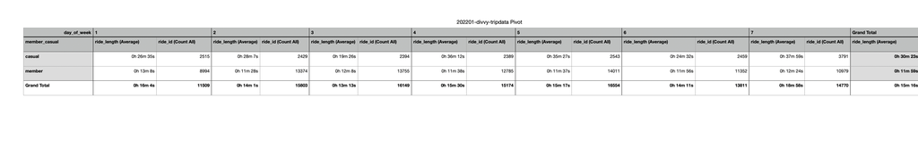

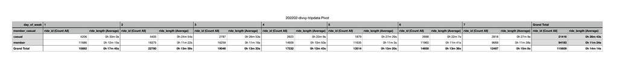

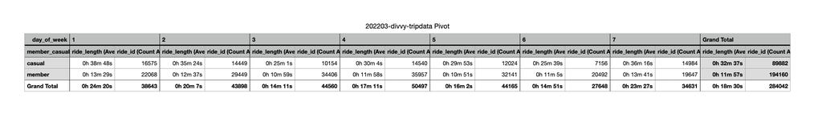

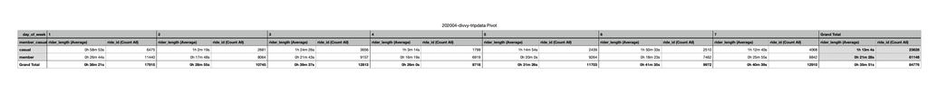

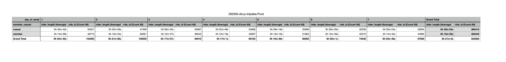

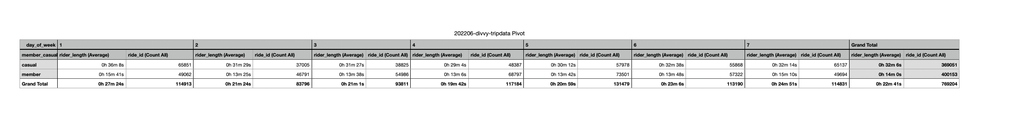

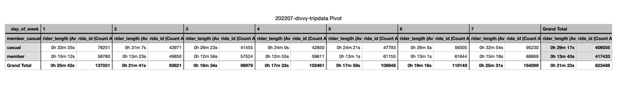

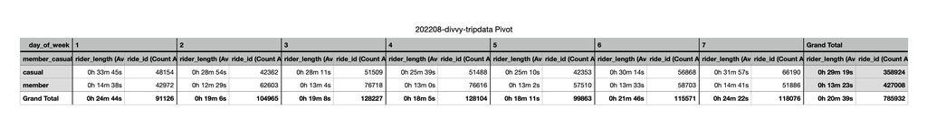

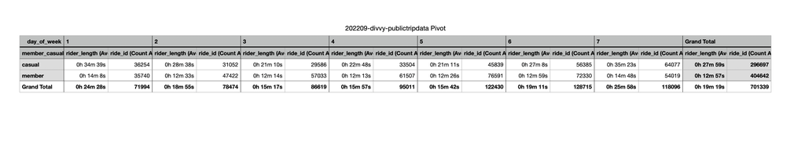

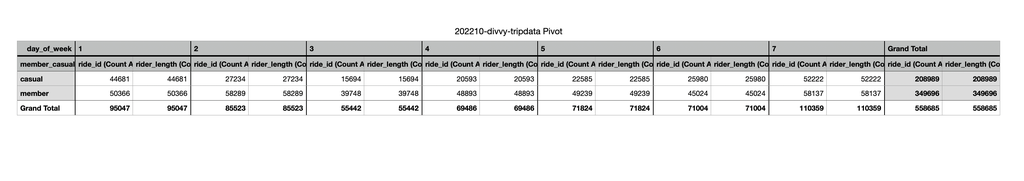

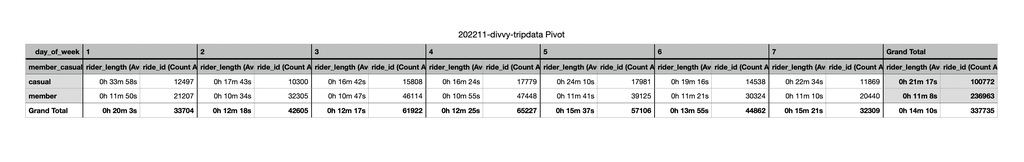

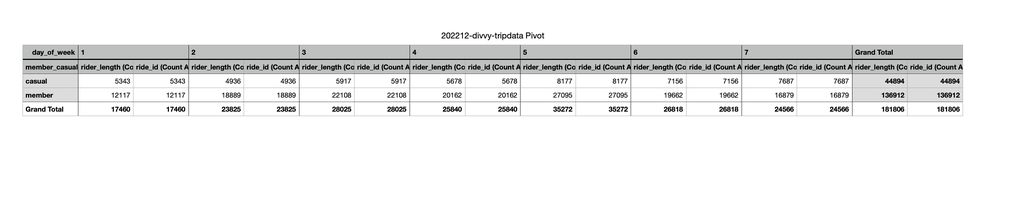

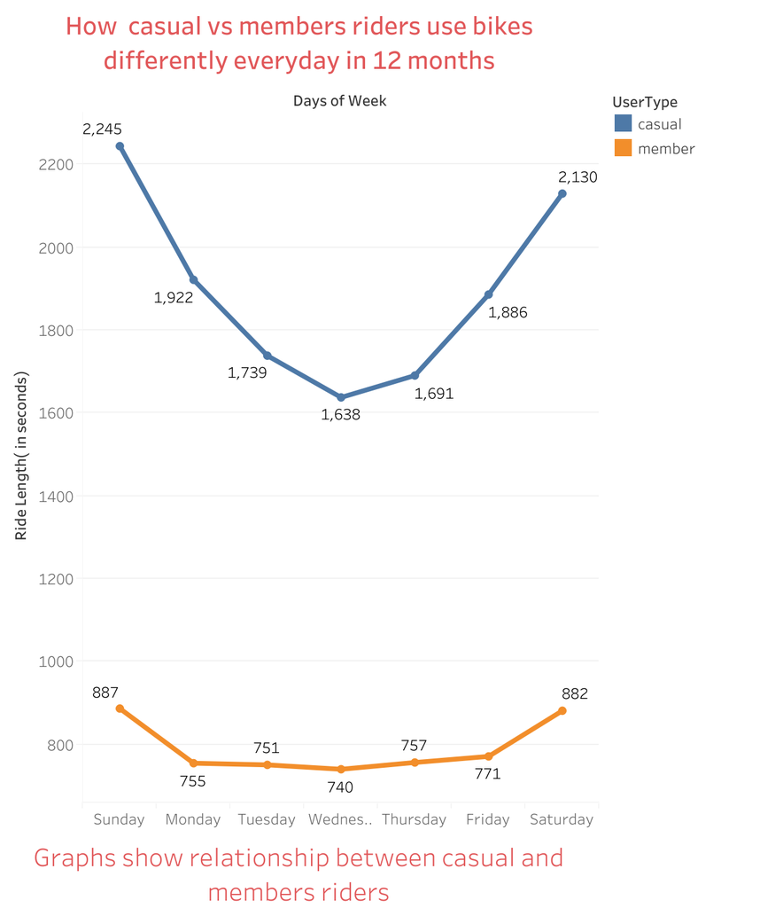

[figure not shown]

-Relationship between usertype with number_of_rides, average_duration in R

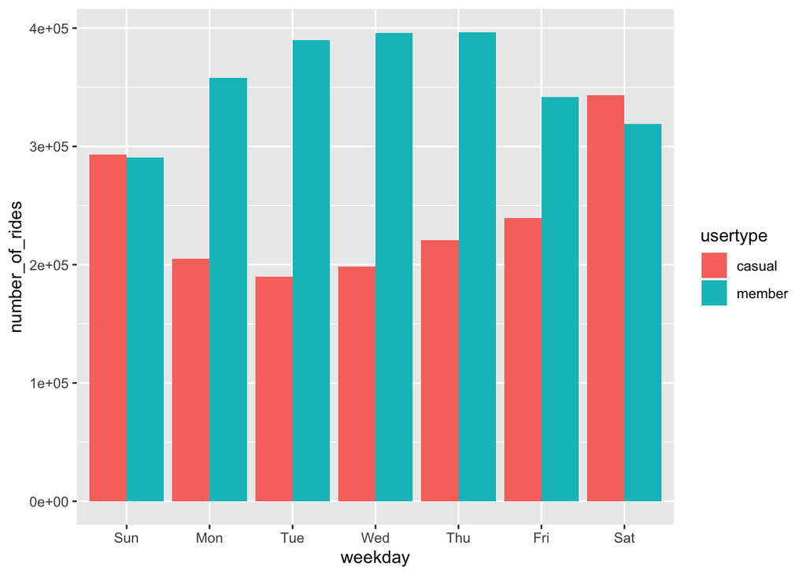

```r
# visualization for usertype with number_of_rides
all_trips_v2 %>%
  na.omit(all_trips_v2) %>% # get rid of NA
  mutate(weekday = wday(start_time, label = TRUE)) %>%  # create weekday field
  group_by(usertype, weekday) %>%  # group usertype and weekday
  summarise(number_of_rides = n()
            ,average_duration = mean(ride_length)) %>%      # calculate number of rides and duration
  arrange(usertype, weekday)%>%  #sort usertype and weekday
  # create a graph
ggplot(aes(x = weekday, y = number_of_rides, fill = usertype)) +
  geom_col(position = "dodge")
```

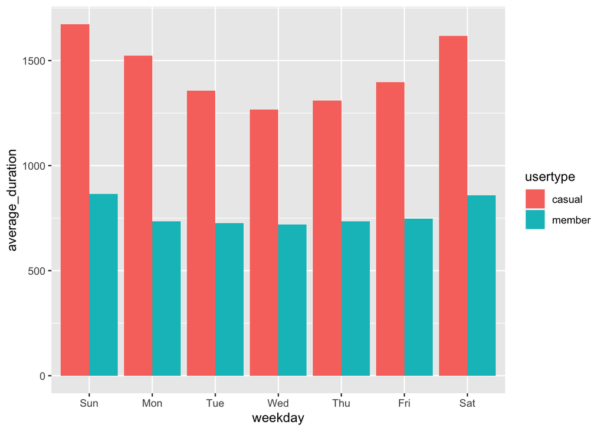

```r
#visualization for average duration
all_trips_v2 %>%
  na.omit(all_trips_v2) %>%
  mutate(weekday = wday(start_time, label = TRUE)) %>%
  group_by(usertype, weekday) %>%
  summarise(number_of_rides = n()
            ,average_duration = mean(ride_length)) %>%
  arrange(usertype, weekday)  %>%
  # create graph
  ggplot(aes(x = weekday, y = average_duration, fill = usertype)) +
  geom_col(position = "dodge")
```

## Act

-My top 3 recommendations are:

- Since we have more members riders than casual ones, we don’t really need to do anything else since everyone is doing great, I would rather recommend giving annual anniversary gift to members in our program, so they could stay longer.
- Because casual have spent more time on bike, I would recommend a first-time purchases bonus, so they can have all benefits from long-time membership with lower fee for first year
- To wrap up, many people have days off on weekend, so create a meeting/club that member/casual people can join together, to make connection and create a healthy lifestyle. The more casual joins, the more chance they would likely to buy a membership.